Back to [jeromewilliams.net](https://www.jeromewilliams.net/)

# Predicting BGG ratings from boardgame characteristics

**Jerome Williams**  
**2024 March 9**

This notebook investigates how well average boardgame ratings from [BoardGameGeek](https://boardgamegeek.com) (BGG) can be predicted from boardgame metadata (number of players, playing time, mechanics, etc.).

We will consider the prediction question from the point of view of a hypothetical boardgame publisher, trying to predict whether the game will be a hit or not in advance of release. Thus, we will rely only on intrinsic characteristics of the game, such as the number of players, playing time, themes, mechanics, and designers, and will not consider as possible predictors any "post-release" data, such as the number of ratings on BGG or the game's publisher.

## Preamble

Let's first load some modules we will need.

```python
import pandas as pd
import numpy as np
import matplotlib.pyplot as plt
import seaborn as sns
import xgboost as xgb

input_path = 'input/bggdata/'


plt.rcParams["font.family"] = "Arial"
plt.rcParams['grid.linestyle'] = 'solid'
plt.rcParams['axes.labelcolor'] = '0.2'
plt.rcParams['grid.color'] = '0.9'
plt.rcParams['xtick.color'] = '0.3'
plt.rcParams['ytick.color'] = '0.3'
plt.rcParams['axes.edgecolor'] = '0.3'
plt.rcParams['axes.titleweight']  = 'bold'
plt.rcParams['axes.facecolor'] = 'white'
```

## Data

We are using the BGG data from boardgamegeek.com, which I downloaded from [Jen Watkins' page on Kaggle](https://www.kaggle.com/datasets/threnjen/board-games-database-from-boardgamegeek?resource=download).

The dataset has several tables, described below.

| Filename | Description |
| --- | --- |
| artists_reduced.csv | Artists associated with each game, stored in one-hot format. |
| designers_reduced.csv | Designers associated with each game, stored in one-hot format. |
| games.csv | Tabular data for each boardgame, including year published, minimum and maximum number of players, and average rating. |
| mechanics.csv | Game mechanics associated with each boardgame, stored in one-hot format. |
| publishers_reduced.csv | Publishers associated with each game, stored in one-hot format. |
| ratings_distribution.csv | The distribution of ratings for each game, stored as, for each numerical rating (e.g., 7.5), the number of times the boardgame has received that rating. |
| subcategories.csv | Subcategories associated with each game. Example subcategories are "Exploration," "Miniatures," "Territory Building," and "Card Game." Categories, as opposed to subcategories, are stored in games.csv. |
| themes.csv | Themes associated with each game. Example themes are "World War I", "Humor", and "Traffic". |
| user_ratings.csv | This seems to be a complete set of ratings data. Each row is a boardgame, username, and numerical rating. |

For this analysis, we will use *games.csv*, *mechanics.csv*, *designers_reduced.csv*, *subcategories.csv* and *themes.csv*.

```python
games = pd.read_csv(input_path + 'games.csv')
mechanics = pd.read_csv(input_path + 'mechanics.csv')
subcategories = pd.read_csv(input_path + 'subcategories.csv')
designers = pd.read_csv(input_path + 'designers_reduced.csv')
themes = pd.read_csv(input_path + 'themes.csv')
```

## Initial exploration

Let's first split our dataset into training and test datasets. The plots that follow will be based on the training data only.

```python
train = games.sample(frac=0.8, random_state=12345)
test = games.drop(train.index)

print(f"Total: {games.shape}")
print(f"Train: {train.shape}")
print(f"Test: {test.shape}")
```

```
Total: (21925, 48)
Train: (17540, 48)
Test: (4385, 48)
```

Our dataset has 21,925 games. We create an 80%/20% train/test split, which results in a training set of 17,540 observations and a test set of 4,385 observations.

### Rating data

First, let's look at the histogram of average ratings.

Our dataset includes both the "Average Rating" (raw average of user ratings, `AvgRating` in *games.csv*) and the “BGG Rating", a modified version of "Average Rating". The BGG Rating (`BayesAvgRating` in *games.csv*) modifies "Average Rating" by adding some number of dummy ratings with scores of 5.5 (out of 10) to the set of ratings, which has the effect of pulling ratings--especially those for games with few votes--closer to the middle ([BoardGameGeek](https://boardgamegeek.com/wiki/page/BoardGameGeek_FAQ)).

According to BoardGameGeek, the BGG Rating is used on the site to “prevent games with relatively few votes climbing to the top of the BGG Ranks” ([BoardGameGeek](https://boardgamegeek.com/wiki/page/BoardGameGeek_FAQ)).

Let's look at the distribution of `AvgRating` and `BayesAvgRating`.

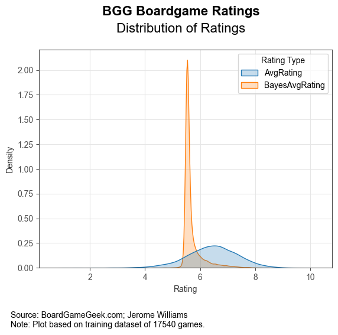

```python
plot_data = train.melt(id_vars = ['BGGId'],value_vars=['AvgRating', 'BayesAvgRating'], var_name='Rating Type', value_name='Rating')
ax = sns.kdeplot(data=plot_data, x="Rating", hue="Rating Type", fill=True)
# plt.show()

fig = ax.get_figure()

ax.grid(True)
ax.set_axisbelow(True)


# title
fig.text(0.5, 1, "BGG Boardgame Ratings", ha='center', weight='bold', size = 16)
# subtitle
fig.text(0.5, 0.94, "Distribution of Ratings", ha='center', weight='normal', size = 16)
# caption
caption_str = f"Source: BoardGameGeek.com; Jerome Williams\nNote: Plot based on training dataset of {len(train)} games."
fig.text(0.05, -0.1, caption_str, ha='left', size = 10)

ax.set_xlabel('Rating')
ax.set_ylabel('Density')

plt.savefig("output/03_avg_vs_bgg_rating_distn.pdf", format="pdf", bbox_inches = 'tight')
```

#### Boardgames with at least 1,000 reviews

If we filter to games with at least 1,000 reviews, the two distributions should be more similar.

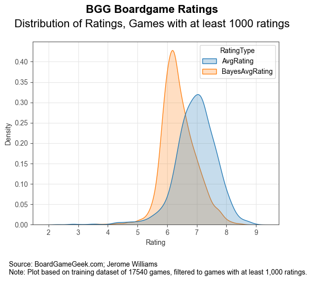

```python
plot_data = (train[train['NumUserRatings'] > 1000]
             .melt(id_vars = ['BGGId'],
                   value_vars=['AvgRating', 'BayesAvgRating'],
                   var_name='RatingType',
                   value_name='Rating')
                   )
ax = sns.kdeplot(plot_data, x="Rating", hue="RatingType", fill=True)
fig = ax.get_figure()

ax.grid(True)
ax.set_axisbelow(True)

# title
fig.text(0.5, 1, "BGG Boardgame Ratings", ha='center', weight='bold', size = 16)
# subtitle
fig.text(0.5, 0.94, "Distribution of Ratings, Games with at least 1000 ratings", ha='center', weight='normal', size = 16)
# caption
caption_str = f"Source: BoardGameGeek.com; Jerome Williams\nNote: Plot based on training dataset of {len(train)} games, \
filtered to games with at least 1,000 ratings."
fig.text(0.05, -0.1, caption_str, ha='left', size = 10)

ax.set_xlabel('Rating')
ax.set_ylabel('Density')

plt.savefig("output/04_avg_vs_bgg_rating_distn_1000.pdf", format="pdf", bbox_inches = 'tight')
```

Although it is noiser, in this exercise, we will try to predict the "Average Rating" rather than the "BGG Rating".

### Feature engineering

Now that we've examined the target variable, let's look at some of the potential feature variables.

#### Mechanics

First, let's examine the game mechanics variables in *mechanics.csv*.

Before anything else, let's join the `mechanics` data to our training and test set, and focus our review on the training set only, so that we don't contaminate the analysis.

```python
mechanics = pd.read_csv('input/bggdata/mechanics.csv')
train = train.merge(mechanics, on = 'BGGId')
test = test.merge(mechanics, on = 'BGGId')
print(f"After joining mechanics, train: {train.shape}")
print(f"After joining mechanics, test: {test.shape}")
```

```
After joining mechanics, train: (17540, 205)
After joining mechanics, test: (4385, 205)
```

The mechanics data is one-hot encoded, with a column for each mechanic and a row for each game, and a 1 or 0 in each cell indicating whether a certain game uses that mechanic. Thus, we can find the total number of games with each mechanic by summing over all rows.

```python
mechanics_list = mechanics.columns[1:].to_list()

mechanics_sum = train[mechanics_list].sum(axis=0).sort_values(ascending=False)
print('Top 10 mechanics:')
print(mechanics_sum[:10])

print(f'Number of unique mechanics: {len(mechanics_list)}')
```

```
Top 10 mechanics:
Dice Rolling              5207
Hand Management           3596
Set Collection            2352
Variable Player Powers    2172
Hexagon Grid              1975
Simulation                1725
Drafting                  1612
Tile Placement            1458
Modular Board             1355
Grid Movement             1310
dtype: int64
Number of unique mechanics: 157
```

We have 157 different mechanics. The most common mechanic is 'Dice Rolling', which is used by 5,207 games (in the training set).

#### Subcategories

Next, let's join the `subcategories` data. Let's add a prefix of "subcat_" to the column names so that there are no naming conflicts.

```python
subcategories = pd.read_csv('input/bggdata/subcategories.csv')
subcategories_new_columns = ['subcat_' + col for col in subcategories.columns[1:].to_list()]
subcategories.columns = ['BGGId'] + subcategories_new_columns
print(len(subcategories_new_columns))
print(subcategories.columns)

train = train.merge(subcategories, on = 'BGGId')
test = test.merge(subcategories, on = 'BGGId')

print(train.shape, test.shape)
```

```
10
Index(['BGGId', 'subcat_Exploration', 'subcat_Miniatures',
       'subcat_Territory Building', 'subcat_Card Game', 'subcat_Educational',
       'subcat_Puzzle', 'subcat_Collectible Components', 'subcat_Word Game',
       'subcat_Print & Play', 'subcat_Electronic'],
      dtype='object')
(17540, 215) (4385, 215)
```

We have 10 different subcategories: Exploration, Miniatures, Terrritory Building, Card Game, Educational, Puzzle, Collectible components, Word Game, Print & Play, and Electronic.

#### Designers

Next, let's join the `designers` data.

```python
designers = pd.read_csv('input/bggdata/designers_reduced.csv')
designers_columns = designers.columns.to_list()

# print(designers_columns.index('BGGId'))
# print(designers_columns.index('Low-Exp Designer'))

designers_new_columns = ['designer_' + col for col in designers.columns[:1592].to_list()]
designers.columns = designers_new_columns + ['BGGId', 'Low-Exp Designer']

train = train.merge(designers, on = 'BGGId')
test = test.merge(designers, on = 'BGGId')

print(train.shape, test.shape)
```

```
(17540, 1808) (4385, 1808)
```

```python
designers_sum = train[designers_new_columns + ['Low-Exp Designer']].sum(axis=0).sort_values(ascending=False)
print('Top 10 designers:')
print(designers_sum[:10])
print(f'Number of unique designers: {len(designers_new_columns)}')
```

```
Top 10 designers:
Low-Exp Designer            6652
designer_(Uncredited)       1147
designer_Reiner Knizia       260
designer_Joseph Miranda      113
designer_Wolfgang Kramer     103
designer_Richard H. Berg      89
designer_Jim Dunnigan         81
designer_James Ernest         80
designer_Martin Wallace       75
designer_Frank Chadwick       74
dtype: int64
Number of unique designers: 1592
```

Our `designers` data does not include data on every designer on BGG. Instead, designers with 3 or fewer entries are lumped together as "Low-Exp Designer". 6,652 have a Low-Exp Designer among their designers. An additional 1,147 have "(Uncredited)" listed as their designer. Aside from these entry types, the most common designers in the training data are [Reiner Knizia](https://boardgamegeek.com/boardgamedesigner/2/reiner-knizia), [Joseph Miranda](https://boardgamegeek.com/boardgamedesigner/337/joseph-miranda), and [Wolfgang Kramer](https://boardgamegeek.com/boardgamedesigner/7/wolfgang-kramer).

#### Themes

Lastly, let's join the `themes` data.

```python
themes = pd.read_csv('input/bggdata/themes.csv')
themes_new_columns = ['theme_' + col for col in themes.columns[1:].to_list()]
themes.columns = ['BGGId'] + themes_new_columns

train = train.merge(themes, on = 'BGGId')
test = test.merge(themes, on = 'BGGId')
print(train.shape, test.shape)
```

```
(17540, 2025) (4385, 2025)
```

```python
designers_sum = train[themes_new_columns].sum(axis=0).sort_values(ascending=False)
print('Top 10 themes:')
print(designers_sum[:10])
print(f'Number of unique themes: {len(themes_new_columns)}')
```

```
Top 10 themes:
theme_Fantasy                      2110
theme_Science Fiction              1332
theme_Fighting                     1330
theme_Economic                     1221
theme_Animals                      1061
theme_World War II                  996
theme_Humor                         963
theme_Adventure                     924
theme_Movies / TV / Radio theme     859
theme_Medieval                      824
dtype: int64
Number of unique themes: 217
```

Next let's collect our features. We have 5 player count and playtime variables, 157 mechanics, 8 categories, 10 subcategories, 217 themes, and 1593 designers.

```python
feature_vars = (['MinPlayers', 'MaxPlayers', 'MfgPlaytime', 'ComMinPlaytime', 'ComMaxPlaytime',
                'Cat:Thematic',
                'Cat:Strategy',
                'Cat:War',
                'Cat:Family',
                'Cat:CGS',
                'Cat:Abstract',
                'Cat:Party',
                'Cat:Childrens'] +
            mechanics_list +
            subcategories_new_columns +
            designers_new_columns + ['Low-Exp Designer'] +
            themes_new_columns)
X_train = train[feature_vars].copy()
X_test = test[feature_vars].copy()

target_var = 'AvgRating'
y_train = train[target_var]
y_test = test[target_var]
print(X_train.shape, X_test.shape, y_train.shape, y_test.shape)
# print(X_train.head(5))
```

```
(17540, 1990) (4385, 1990) (17540,) (4385,)
```

#### Playing time and player count

Let's also create some different representations of the player count variables. Our data records the minimum and maximum player counts, but the model may do better with explicit variables indicating whether a game can be played 2/3/4/etc. players.

```python
X_train['plays1'] = ((X_train['MinPlayers'] == 1) & (X_train['MaxPlayers'] >= 1)).astype(int)
X_train['plays2'] = ((X_train['MinPlayers'] <= 2) & (X_train['MaxPlayers'] >= 2)).astype(int)
X_train['plays3'] = ((X_train['MinPlayers'] <= 3) & (X_train['MaxPlayers'] >= 3)).astype(int)
X_train['plays4'] = ((X_train['MinPlayers'] <= 4) & (X_train['MaxPlayers'] >= 4)).astype(int)
X_train['plays5'] = ((X_train['MinPlayers'] <= 5) & (X_train['MaxPlayers'] >= 5)).astype(int)
X_train['plays6'] = ((X_train['MinPlayers'] <= 6) & (X_train['MaxPlayers'] >= 6)).astype(int)
X_train['plays7plus'] = (X_train['MaxPlayers'] >= 7).astype(int)
X_train['num_player_counts'] = X_train['MaxPlayers'] - X_train['MinPlayers'] + 1

X_test['plays1'] = ((X_test['MinPlayers'] == 1) & (X_test['MaxPlayers'] >= 1)).astype(int)
X_test['plays2'] = ((X_test['MinPlayers'] <= 2) & (X_test['MaxPlayers'] >= 2)).astype(int)
X_test['plays3'] = ((X_test['MinPlayers'] <= 3) & (X_test['MaxPlayers'] >= 3)).astype(int)
X_test['plays4'] = ((X_test['MinPlayers'] <= 4) & (X_test['MaxPlayers'] >= 4)).astype(int)
X_test['plays5'] = ((X_test['MinPlayers'] <= 5) & (X_test['MaxPlayers'] >= 5)).astype(int)
X_test['plays6'] = ((X_test['MinPlayers'] <= 6) & (X_test['MaxPlayers'] >= 6)).astype(int)
X_test['plays7plus'] = (X_test['MaxPlayers'] >= 7).astype(int)
X_test['num_player_counts'] = X_test['MaxPlayers'] - X_test['MinPlayers'] + 1

print(X_train.shape, X_test.shape)
```

```
(17540, 1998) (4385, 1998)
```

### Variable scaling

Before fitting our model, let's scale the features and target variables.

```python
# scaling
from sklearn.preprocessing import RobustScaler

X_scaler = RobustScaler()

features = X_train.columns

Xtr2 = X_scaler.fit_transform(X_train[features])
Xte2 = X_scaler.transform(X_test[features])

y_scaler = RobustScaler()

ytr2 = y_scaler.fit_transform(y_train.values.reshape(-1, 1))
yte2 = y_scaler.transform(y_test.values.reshape(-1, 1))
```

We use *optuna* to tune the parameters (learning rate and number of trees) and use a TPE (Tree-structured Parzen Estimator) sampler ([arxiv.org](https://arxiv.org/abs/2304.11127)).

```python
import optuna
from optuna.samplers import TPESampler
from sklearn.model_selection import KFold
from sklearn.metrics import mean_squared_error

n = 5
cv = KFold(n, shuffle = True, random_state = 12345)

def objective(trial):

    learning_rate = trial.suggest_float("learning_rate", 0, 0.1)
    n_estimators = trial.suggest_int('n_estimators', 500, 2000)

    scores = []

    for i, (train_index, val_index) in enumerate(cv.split(Xtr2, ytr2)):
        Xtr2_fold, X_val = Xtr2[train_index], Xtr2[val_index]
        ytr2_fold, y_val = ytr2[train_index], ytr2[val_index]

        xgb_model = xgb.XGBRegressor(objective = "reg:squarederror",
                                     verbosity = 0,
                                     learning_rate = learning_rate,
                                     n_estimators = n_estimators
                                    )

        xgb_model.fit(Xtr2_fold, ytr2_fold)

        xgb_preds = xgb_model.predict(X_val)
        score = mean_squared_error(y_val, xgb_preds)

        scores.append(score)

    return np.mean(scores)

study = optuna.create_study(direction = "minimize", sampler = TPESampler())
study.optimize(func = objective, n_trials = 30)
print(study.best_params)
```

[output not shown]

[output cut: 11 more lines]

```
{'learning_rate': 0.09816410797966438, 'n_estimators': 1831}
```

### Results

The optimal set is a learning rate of 0.098 and 1,831 for the number of trees.

Let's now fit the model again (with the best parameters) to the whole training set.

```python
study.best_params

xgb_model_best = xgb.XGBRegressor(objective = "reg:squarederror",
                                     verbosity = 0,
                                     importance_type = 'gain',
                                     **study.best_params
                                    )
xgb_model_best.fit(Xtr2, ytr2)
test_preds = xgb_model_best.predict(Xte2)
test_score = mean_squared_error(yte2, test_preds)
print(f"Test score: {test_score:.4f}")
print(f"RMSE:       {np.sqrt(test_score):.4f}")
```

```
Test score: 0.3003
RMSE:       0.5480
```

We have an RMSE value of 0.548. However, this RMSE is given in terms of the *scaled* target variable, so is not straightforward to interpret. Let's convert back to our original scale and recalculate the RMSE.

```python
y_test_inverted = y_scaler.inverse_transform(yte2).flatten()
test_preds_inverted = y_scaler.inverse_transform(test_preds.reshape(-1, 1)).flatten()

test_df = pd.DataFrame({'y_test': y_test_inverted, 'test_preds': test_preds_inverted})
RMSE_inverted = np.sqrt(mean_squared_error(test_df['y_test'], test_df['test_preds']))
print(f"RMSE: {RMSE_inverted:.4f}")
```

```
RMSE: 0.6633
```

On our original scale, the RMSE is 0.663. This means that the average absolute difference between our predicted ratings and actual ratings is (roughly) 0.66, where ratings are on the 1-10 BGG scale.

### Predictions

Next, let's plot predicted ratings against actual ratings.

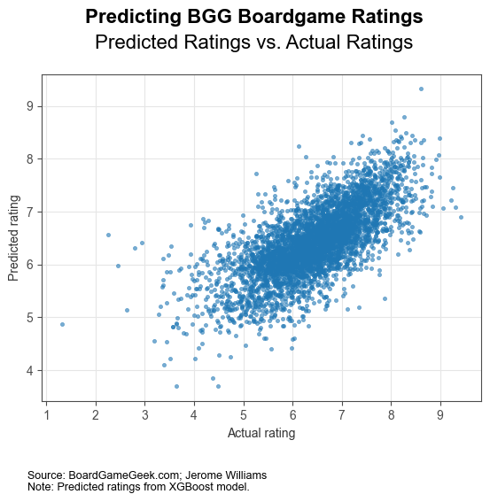

```python
ax = sns.scatterplot(data = test_df, x = 'y_test', y = 'test_preds', alpha = 0.6, marker = '.', edgecolor=None)
fig = ax.get_figure()

ax.set_xlabel('Actual rating')
ax.set_ylabel('Predicted rating')
ax.set_facecolor('white')
ax.grid(True)
ax.set_axisbelow(True)


# title
fig.text(0.5, 1, "Predicting BGG Boardgame Ratings", ha='center', weight='bold', size = 16)

# subtitle
fig.text(0.5, 0.94, "Predicted Ratings vs. Actual Ratings", ha='center', weight='normal', size = 16)

# caption
caption_text = """
Source: BoardGameGeek.com; Jerome Williams
Note: Predicted ratings from XGBoost model."""
fig.text(0.1, -0.10, caption_text, ha='left', size=9)

plt.savefig("output/01_predicted_vs_actual_XGB01.pdf", format="pdf", bbox_inches = 'tight')
```

Reassuringly, we see an upward-sloping between predicted and actual ratings. One interesting fact is that predicted ratings never go below 3.5, even though there are a handful of actual ratings in that range.

## Feature importance

Now that we've fit our model, let's examine feature importance, the degree to which different features contribute to the predicted rating.

The feature importance for our XGBoost model corresponds to the average information gain) across all splits the feature is used in.

```python
importance_df = pd.DataFrame({'feature' : features, 'importance' : xgb_model_best.feature_importances_})
importance_df.sort_values('importance', ascending = False, inplace = True)
```

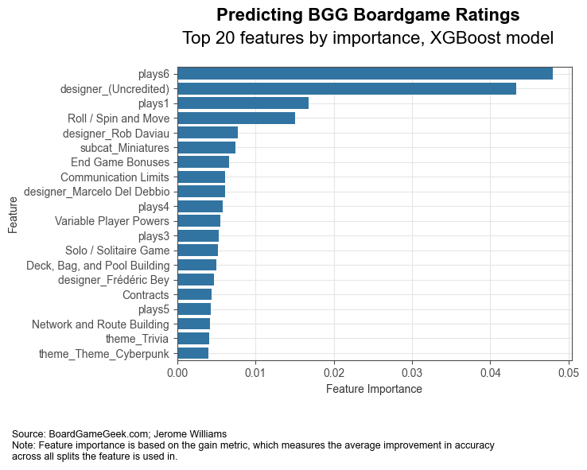

```python
ax = sns.barplot(data = importance_df.head(20), x = 'importance', y = 'feature')
fig = ax.get_figure()

ax.set_axisbelow(True)
ax.grid(True)

# title
fig.text(0.5, 1, "Predicting BGG Boardgame Ratings", ha='center', weight='bold', size = 16)

# subtitle
fig.text(0.5, 0.94, "Top 20 features by importance, XGBoost model", ha='center', weight='normal', size = 16)

# caption
caption_text = """Source: BoardGameGeek.com; Jerome Williams
Note: Feature importance is based on the gain metric, which measures the average improvement in accuracy
across all splits the feature is used in."""

fig.text(-0.2, -0.15, caption_text, ha='left', size = 9)

ax.set_xlabel('Feature Importance')
ax.set_ylabel('Feature')
plt.show()
# plt.savefig("output/02_variable_importances_XGB01.pdf", format="pdf", bbox_inches = 'tight')
```